# FE8828 Assignment for Exploratory Data Analysis

# Data Insight 4: Age, Default and Home Loan

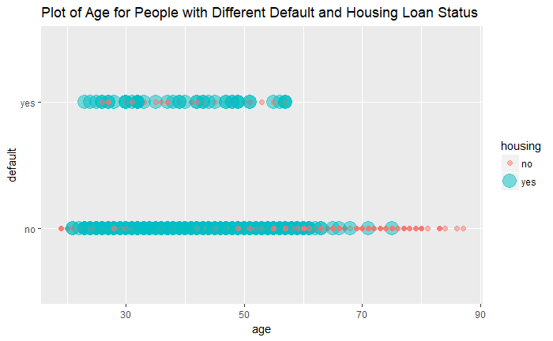

# Data Insight 5: Age, Balance and Marital Status

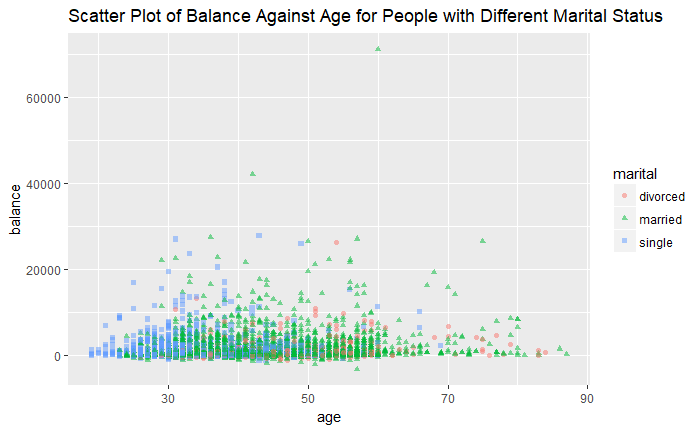

The above scatter plot illustrates the relationship between age, balance and marital status. In general, balance increases with age till around 40+ years old and decreases thereafter. Majority of the population has a balance of less than 10000. In addition, majority of the population aged 30 and above are married and the people who have higher balance (>10000) are mostly married. This may imply that people who are married generally has to take a higher loan to support the family.

# Data Insight 6: Age, Job and Education

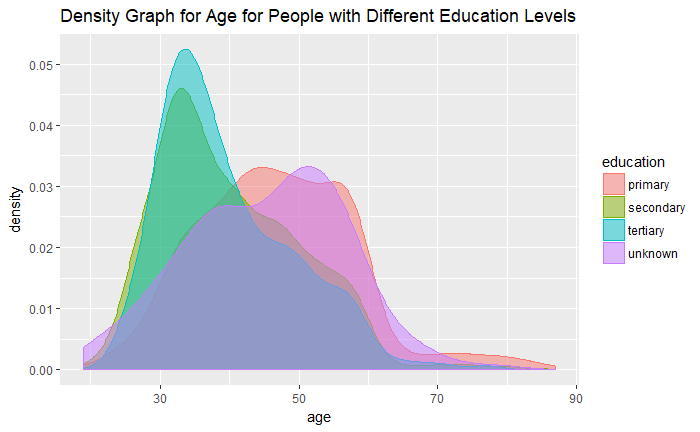

The above density plot illustrates the age distribution of the people with differnt education levels.People with tertiary and secondary education are generally in their 30s. People with primary education are generally in their 40s and 50s. This may indicate the evolution of the society where in the past, education was not as important and people who were born in that era were not as educated. Hence, people who are younger (30s) have higher education levels compared to those who are older (40s, 50s).

# Data Insight 7: Age distribution in people with and without housing loan

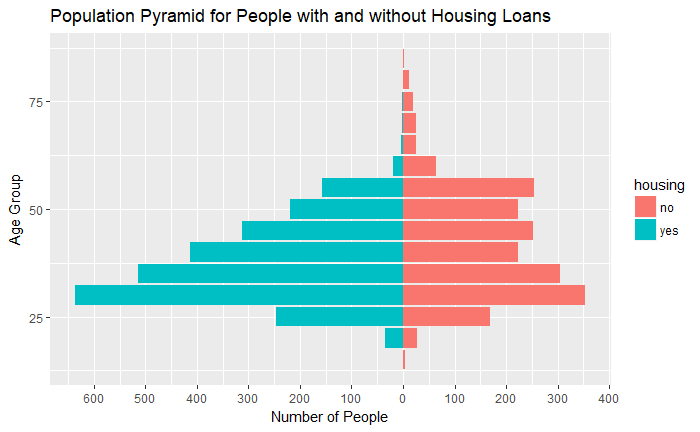

The above population pyramid for the people with and without housing loans. The population distributions are pretty similar in these 2 groups, with a peak at the low 30s.The proportion of people with housing loan in each age group decreases with an increasing age. This may imply that people who are older may have already paid off their housing loans then. While a higher percentage people at young age may have just started their family or have a career and just bought a house, resulting in a higher proportion of people in the younger age group to have a housing loan.

# Data Insight 8: Job and Loan

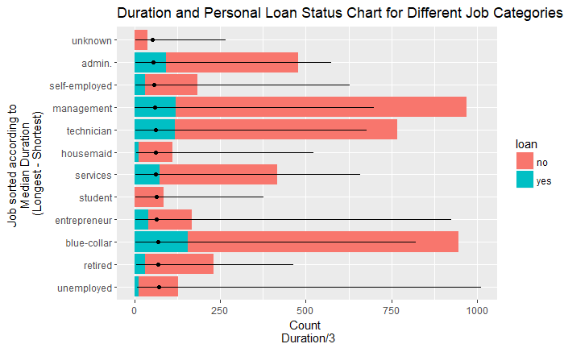

The above plot shows the relationship between personal loan status, job and duration. It can be seen that unemployed has the highest median duration and the largest range for duration. This can be explained that unemployed may be split into 2 groups - one group who are in a bad mood due to their unemployment and are not interested in talks and another are those who has alot of unhappiness and tend to resent to the telemarketer about their life and thus a longer duration of the calls.

# Data Insight 9: Duration for people with and without personal loans

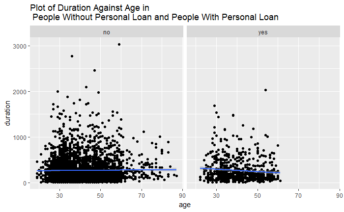

# Data Insight 10

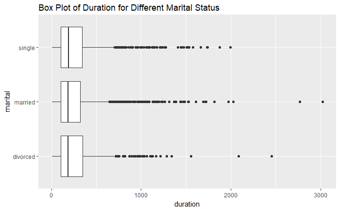